# Neurologic Disease and HMPV Infection Risk: NVSN Multisite Analysis

2016-2026, Complete Case Analysis

Overview

This document presents a complete case analysis investigating whether children with neurologic/neuromuscular disease experience increased risk of HMPV (human metapneumovirus) infection and disease severity across 7 NVSN sites from 2016-2026. We compare findings to a previous single-site (Pittsburgh) analysis that found neurologic disease associated with 1.75× higher odds of HMPV infection and 4.80× higher odds of severe illness.

```r
library(data.table)
library(gtsummary)
library(ggplot2)
library(ggpubr)
library(MASS)
library(brant)
source("wald_function.R")
```

```r
dat <- fread("Data/Pitt_Anna_HMPV_SEP26.csv", na.strings = "")
```

# 1 Data Preparation

```r
# Neurologic/neuromuscular disease status (explicit NA handling)
dat[, neuro.status := fcase(
  c_unuerologic == 1, "Neurologic Disease",
  c_unuerologic == 0, "No Neurologic Disease")]
dat[, neuro.status := factor(
  neuro.status,
  c("No Neurologic Disease", "Neurologic Disease"))]
```

```r
# Primary outcome: HMPV infection status
dat[, hmpv.pos := tmpv == 1]
dat[, hmpv.status := factor(
  hmpv.pos, c(TRUE, FALSE), c("HMPV-Pos", "HMPV-neg"))]

# Secondary outcome: Illness severity (5-level ordinal)
# First, create helper variables for O2/respiratory support
dat[c_finalstatus == 1, c_hospO2 := fcase(
  c_suppoxy == 1, TRUE, c_blowby==1, TRUE, c_cpap==1, TRUE,
  inptICU == 1, TRUE,
  c_intubated == 1, TRUE,
  inptEcmo == 1, TRUE,
  default = FALSE)]  # If admitted but no ICU/intubation/ECMO markers

dat[, c_mv_ecmo := fcase(
  c_intubated == 1, TRUE,
  inptEcmo == 1, TRUE,
  default = FALSE)]

dat[, c_icu := inptICU == 1]

# Construct 5-level severity outcome
dat[, severity := fcase(
  c_finalstatus == 2, 1L,  # ED discharge
  c_finalstatus == 1 & !c_hospO2, 2L,  # Admitted, no support
  c_finalstatus == 1 & c_hospO2 & !c_icu, 3L,  # Admitted with O2/resp support
  c_finalstatus == 1 & c_icu & !c_mv_ecmo, 4L,  # ICU admission
  c_finalstatus == 1 & c_mv_ecmo, 5L)]  # MV/ECMO

dat[, severity := factor(
  severity, 1:5,
  c("ED discharge", "Admitted - no support", "Admitted - O2/resp support",
    "ICU admission", "Mechanical ventilation/ECMO"))]
```

```r
# Site
dat[, studysite := factor(
  studysite, c(8, 1:6),
  c("Pittsburgh", "Nashville", "Rochester", "Cincinnati", "Seattle", "Houston",
    "Kansas City"))]

# Demographics
dat[, sexch := factor(sexch, 2:1, c("Female", "Male"))]
dat[, c_race_int := factor(
  c_race_int, c(1, 2, 4, 3, 8),
  c("White NH", "Black NH", "Hispanic", "Other NH", "Unknown"))]

# Insurance (verify levels in data)
dat[, insurance.cat := factor(
  scrinsurance, c(1, 2, 3, 4, 8),
  c("Private", "Public", "Both Public/Private", "None", "Unknown"))]

# Season - Exclude Pilot year
dat[, c_ariyear := factor(
  c_ariyear,
  c(2:11),
  c("2016-17", "2017-18", "2018-19", "2019-20", "2020-21",
    "2021-22", "2022-23", "2023-24", "2024-25", "2025-26"))]

# Comorbidities - explicit TRUE/FALSE/NA encoding
dat[, respiratory.cond := fcase(
  c_uresp == 1, TRUE,
  c_uresp == 0, FALSE)]

dat[, cardiovasc.cond := fcase(
  c_ucardiovasc == 1, TRUE,
  c_ucardiovasc == 0, FALSE)]

dat[, immunocomp.cond := fcase(
  c_uoncolimmu == 1, TRUE,
  c_uoncolimmu == 0, FALSE)]

# Prematurity - default assume full term
dat[, prematurity.cond := fcase(
  c_uprem == 1, TRUE,
  default=FALSE)]
```

```r
# Define required variables
required.vars <- c(
  "hmpv.pos", "neuro.status", "c_ageyears", "sexch", "c_race_int",
  "insurance.cat", "respiratory.cond", "cardiovasc.cond",
  "immunocomp.cond", "prematurity.cond", "studysite", "c_ariyear")

# Create complete case indicator
dat[, complete.case := complete.cases(.SD), .SDcols = required.vars]

# Document exclusions
exclusion.summary <- dat[, .(
  total = .N,
  missing_hmpv = sum(is.na(hmpv.pos)),
  missing_neuro = sum(is.na(neuro.status)),
  missing_age = sum(is.na(c_ageyears)),
  missing_sex = sum(is.na(sexch)),
  missing_race = sum(is.na(c_race_int)),
  missing_insurance = sum(is.na(insurance.cat)),
  missing_resp = sum(is.na(respiratory.cond)),
  missing_cardio = sum(is.na(cardiovasc.cond)),
  missing_immuno = sum(is.na(immunocomp.cond)),
  missing_prem = sum(is.na(prematurity.cond)),
  missing_site = sum(is.na(studysite)),
  missing_year = sum(is.na(c_ariyear)),
  complete_cases = sum(complete.case))]

# Subset to complete cases
inc <- dat[complete.case == TRUE]
```

# 2 Study Population

Table 1 summarizes case inclusion. Starting with 136,156 total ARI cases, we retained 123,903 cases with complete data on HMPV test results, neurologic status, demographics, and comorbidities.

Table 1: Case inclusion summary

| total | missing_hmpv | missing_neuro | missing_sex | complete_cases |
| --- | --- | --- | --- | --- |
| 136,156 | 4,476 | 9,082 | 26 | 123,903 |

# 3 Primary Analysis: HMPV Infection Risk

```r
# Unadjusted model
fit.unadj <- glm(
  hmpv.pos ~ neuro.status,
  data = inc,
  family = binomial)

# Adjusted model
fit.adj <- glm(
  hmpv.pos ~ neuro.status + c_ageyears + sexch + c_race_int +
    insurance.cat + respiratory.cond + cardiovasc.cond +
    immunocomp.cond + prematurity.cond + studysite + c_ariyear,
  data = inc,
  family = binomial)
```

```r
# Descriptive statistics
desc.labs <- list(
  neuro.status = "Neurologic/neuromuscular disease",
  c_ageyears = "Age (years)",
  sexch = "Sex",
  c_race_int = "Race/ethnicity",
  insurance.cat = "Insurance type",
  respiratory.cond = "Respiratory condition",
  cardiovasc.cond = "Cardiovascular condition",
  immunocomp.cond = "Immunocompromised",
  prematurity.cond = "Prematurity",
  studysite = "Study site",
  c_ariyear = "Season")

tbl.desc <- tbl_summary(
  inc,
  by = hmpv.status,
  include = names(desc.labs),
  label = desc.labs,
  missing = "no") |>
  add_overall(last = TRUE)

# Unadjusted ORs
tbl.unadj <- tbl_regression(
  fit.unadj,
  tidy_fun = tidy.glm.wald,
  exponentiate = TRUE,
  include = neuro.status,
  label = desc.labs) |>
  bold_p() |>
  modify_header(estimate = "**OR**")

# Adjusted ORs
tbl.adj <- tbl_regression(
  fit.adj,
  label = desc.labs,
  tidy_fun = tidy.glm.wald,
  exponentiate = TRUE,
  show_single_row = c(respiratory.cond, cardiovasc.cond,
                      immunocomp.cond, prematurity.cond)) |>
  bold_p() |>
  modify_header(estimate = "**AOR**") |>
  remove_abbreviation() |>
  modify_abbreviation("AOR = Adjusted Odds Ratio")
```

Table 2 presents HMPV infection risk analysis. The left panel shows descriptive statistics stratified by HMPV status. The middle panel shows unadjusted odds ratios, and the right panel shows adjusted odds ratios controlling for demographics, comorbidities, site, and season.

Table 2: HMPV infection risk by neurologic status

| **Characteristic** | Descriptive **HMPV-Pos** N = 6,204 | Descriptive **HMPV-neg** N = 117,699 | Descriptive **Overall** N = 123,903 | Unadjusted **OR** | Unadjusted **95% CI** | Unadjusted **p-value** | Adjusted **AOR** | Adjusted **95% CI** | Adjusted **p-value** |
| --- | --- | --- | --- | --- | --- | --- | --- | --- | --- |
| Neurologic/neuromuscular disease |  |  |  |  |  |  |  |  |  |
| No Neurologic Disease | 5,791 (93%) | 110,479 (94%) | 116,270 (94%) | — | — |  | — | — |  |
| Neurologic Disease | 413 (6.7%) | 7,220 (6.1%) | 7,633 (6.2%) | 1.09 | 0.98, 1.21 | 0.10 | 1.10 | 0.99, 1.23 | 0.085 |
| Age (years) | 2 (0, 4) | 2 (0, 6) | 2 (0, 6) |  |  |  | 0.93 | 0.92, 0.94 | <0.001 |
| Sex |  |  |  |  |  |  |  |  |  |
| Female | 2,875 (46%) | 52,781 (45%) | 55,656 (45%) |  |  |  | — | — |  |
| Male | 3,329 (54%) | 64,918 (55%) | 68,247 (55%) |  |  |  | 0.91 | 0.86, 0.95 | <0.001 |
| Race/ethnicity |  |  |  |  |  |  |  |  |  |
| White NH | 1,908 (31%) | 37,040 (31%) | 38,948 (31%) |  |  |  | — | — |  |
| Black NH | 1,651 (27%) | 35,288 (30%) | 36,939 (30%) |  |  |  | 0.98 | 0.91, 1.06 | 0.6 |
| Hispanic | 1,866 (30%) | 31,100 (26%) | 32,966 (27%) |  |  |  | 1.14 | 1.05, 1.24 | 0.001 |
| Other NH | 680 (11%) | 12,482 (11%) | 13,162 (11%) |  |  |  | 1.02 | 0.93, 1.12 | 0.7 |
| Unknown | 99 (1.6%) | 1,789 (1.5%) | 1,888 (1.5%) |  |  |  | 1.11 | 0.90, 1.36 | 0.3 |
| Insurance type |  |  |  |  |  |  |  |  |  |
| Private | 4,030 (65%) | 76,003 (65%) | 80,033 (65%) |  |  |  | — | — |  |
| Public | 1,632 (26%) | 31,971 (27%) | 33,603 (27%) |  |  |  | 0.95 | 0.89, 1.02 | 0.14 |
| Both Public/Private | 90 (1.5%) | 2,004 (1.7%) | 2,094 (1.7%) |  |  |  | 0.87 | 0.70, 1.08 | 0.2 |
| None | 346 (5.6%) | 6,246 (5.3%) | 6,592 (5.3%) |  |  |  | 1.09 | 0.97, 1.22 | 0.13 |
| Unknown | 106 (1.7%) | 1,475 (1.3%) | 1,581 (1.3%) |  |  |  | 1.09 | 0.88, 1.33 | 0.4 |
| Respiratory condition | 1,267 (20%) | 24,868 (21%) | 26,135 (21%) |  |  |  | 1.10 | 1.03, 1.18 | 0.007 |
| Cardiovascular condition | 378 (6.1%) | 5,276 (4.5%) | 5,654 (4.6%) |  |  |  | 1.26 | 1.12, 1.41 | <0.001 |
| Immunocompromised | 93 (1.5%) | 2,088 (1.8%) | 2,181 (1.8%) |  |  |  | 0.93 | 0.75, 1.15 | 0.5 |
| Prematurity | 760 (12%) | 10,308 (8.8%) | 11,068 (8.9%) |  |  |  | 1.30 | 1.20, 1.41 | <0.001 |
| Study site |  |  |  |  |  |  |  |  |  |
| Pittsburgh | 1,203 (19%) | 19,124 (16%) | 20,327 (16%) |  |  |  | — | — |  |
| Nashville | 884 (14%) | 16,954 (14%) | 17,838 (14%) |  |  |  | 0.77 | 0.70, 0.85 | <0.001 |
| Rochester | 505 (8.1%) | 10,518 (8.9%) | 11,023 (8.9%) |  |  |  | 0.75 | 0.68, 0.84 | <0.001 |
| Cincinnati | 654 (11%) | 17,477 (15%) | 18,131 (15%) |  |  |  | 0.62 | 0.56, 0.68 | <0.001 |
| Seattle | 854 (14%) | 14,052 (12%) | 14,906 (12%) |  |  |  | 0.91 | 0.83, 1.00 | 0.061 |
| Houston | 1,190 (19%) | 20,381 (17%) | 21,571 (17%) |  |  |  | 0.83 | 0.76, 0.92 | <0.001 |
| Kansas City | 914 (15%) | 19,193 (16%) | 20,107 (16%) |  |  |  | 0.79 | 0.72, 0.86 | <0.001 |
| Season |  |  |  |  |  |  |  |  |  |
| 2016-17 | 565 (9.1%) | 9,374 (8.0%) | 9,939 (8.0%) |  |  |  | — | — |  |
| 2017-18 | 451 (7.3%) | 8,061 (6.8%) | 8,512 (6.9%) |  |  |  | 0.92 | 0.81, 1.04 | 0.2 |
| 2018-19 | 524 (8.4%) | 8,992 (7.6%) | 9,516 (7.7%) |  |  |  | 0.91 | 0.81, 1.03 | 0.2 |
| 2019-20 | 330 (5.3%) | 7,185 (6.1%) | 7,515 (6.1%) |  |  |  | 0.75 | 0.65, 0.86 | <0.001 |
| 2020-21 | 20 (0.3%) | 8,675 (7.4%) | 8,695 (7.0%) |  |  |  | 0.04 | 0.02, 0.06 | <0.001 |
| 2021-22 | 776 (13%) | 12,253 (10%) | 13,029 (11%) |  |  |  | 1.04 | 0.93, 1.16 | 0.5 |
| 2022-23 | 842 (14%) | 10,106 (8.6%) | 10,948 (8.8%) |  |  |  | 1.41 | 1.26, 1.58 | <0.001 |
| 2023-24 | 1,098 (18%) | 19,274 (16%) | 20,372 (16%) |  |  |  | 0.99 | 0.89, 1.10 | 0.8 |
| 2024-25 | 852 (14%) | 19,199 (16%) | 20,051 (16%) |  |  |  | 0.77 | 0.69, 0.86 | <0.001 |
| 2025-26 | 746 (12%) | 14,580 (12%) | 15,326 (12%) |  |  |  | 0.91 | 0.81, 1.02 | 0.11 |

Abbreviations: AOR = Adjusted Odds Ratio, CI = Confidence Interval, OR = Odds Ratio

# 4 Site-Level Variation

```r
# Calculate HMPV positivity rates by site, neurologic status, and CoAg period
inc[, period := fcase(
  c_ariyear %in% c("2016-17", "2017-18", "2018-19", "2019-20",
                   "2020-21"), "CoAg1",
  default = "CoAg2")]
rates.by.site <- inc[, .(
  hmpv.rate = mean(hmpv.pos, na.rm = TRUE),
  n.pos = sum(hmpv.pos, na.rm = TRUE),
  n.total = .N),
  by = .(neuro.status, studysite, period)]

# Add 95% CI using normal approximation
rates.by.site[, se := sqrt(hmpv.rate * (1 - hmpv.rate) / n.total)]
rates.by.site[, lwr := pmax(0, hmpv.rate - 1.96 * se)]
rates.by.site[, upr := pmin(1, hmpv.rate + 1.96 * se)]
```

Figure 1 shows HMPV positivity rates by coag period, study site and neurologic status. Error bars represent 95% confidence intervals.

Figure 1: HMPV infection rates by site and neurologic status

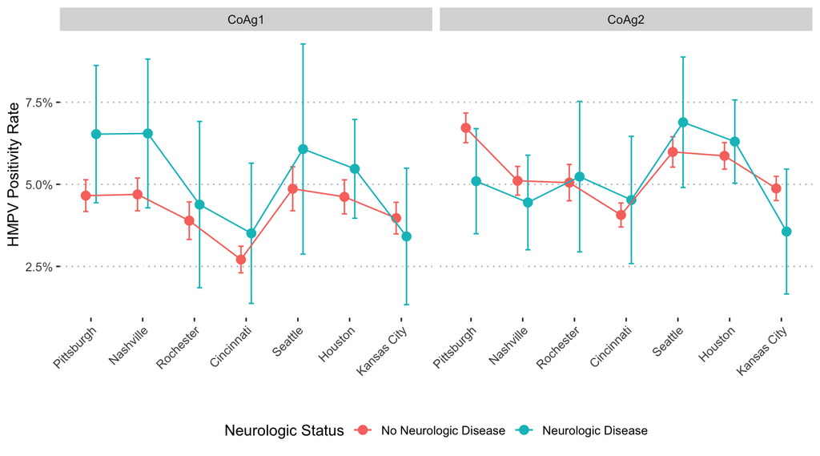

# 5 Secondary Analysis: Disease Severity Among HMPV+ Cases

```r
# Subset to HMPV-positive cases
hmpv.cases <- inc[hmpv.pos == TRUE & !is.na(severity)]

# Descriptive summary by severity level
tbl.sev.desc <- tbl_summary(
  hmpv.cases,
  by = severity,
  include = c(neuro.status, c_ageyears, sexch, c_race_int, insurance.cat,
              respiratory.cond, cardiovasc.cond, immunocomp.cond,
              prematurity.cond, studysite, c_ariyear),
  label = desc.labs,
  missing = "no")

# Proportional odds model
fit.severity <- polr(
  severity ~ neuro.status + c_ageyears + sexch + c_race_int +
    insurance.cat + respiratory.cond + cardiovasc.cond +
    immunocomp.cond + prematurity.cond + studysite + c_ariyear,
  data = hmpv.cases,
  Hess = TRUE)

tbl.sev.adj <- tbl_regression(
  fit.severity,
  label = desc.labs,
  tidy_fun = tidy.glm.wald,
  exponentiate = TRUE,
  show_single_row = c(respiratory.cond, cardiovasc.cond,
                      immunocomp.cond, prematurity.cond)) |>
  bold_p() |>
  modify_header(estimate = "**OR**") |>
  modify_footnote(
    estimate ~ "Proportional odds ratio for elevated severity")
```

Table 3 presents illness severity among HMPV-positive cases. The proportional odds model estimates the odds of being in a higher severity category. The proportional odds assumption was tested using the Brant test; see Table 4 for results.

Table 3: Illness severity among HMPV-positive cases

| **Characteristic** | Descriptive **ED discharge** N = 2,591 | Descriptive **Admitted - no support** N = 907 | Descriptive **Admitted - O2/resp support** N = 1,326 | Descriptive **ICU admission** N = 461 | Descriptive **Mechanical ventilation/ECMO** N = 97 | Adjusted OR **OR** | Adjusted OR **95% CI** | Adjusted OR **p-value** |
| --- | --- | --- | --- | --- | --- | --- | --- | --- |
| Neurologic/neuromuscular disease |  |  |  |  |  |  |  |  |
| No Neurologic Disease | 2,519 (97%) | 841 (93%) | 1,199 (90%) | 370 (80%) | 60 (62%) | — | — |  |
| Neurologic Disease | 72 (2.8%) | 66 (7.3%) | 127 (9.6%) | 91 (20%) | 37 (38%) | 2.93 | 2.37, 3.61 | <0.001 |
| Age (years) | 2 (0, 4) | 1 (0, 3) | 1 (0, 3) | 1 (0, 3) | 1 (0, 5) | 0.93 | 0.91, 0.95 | <0.001 |
| Sex |  |  |  |  |  |  |  |  |
| Female | 1,179 (46%) | 410 (45%) | 655 (49%) | 213 (46%) | 48 (49%) | — | — |  |
| Male | 1,412 (54%) | 497 (55%) | 671 (51%) | 248 (54%) | 49 (51%) | 0.85 | 0.77, 0.95 | 0.003 |
| Race/ethnicity |  |  |  |  |  |  |  |  |
| White NH | 588 (23%) | 379 (42%) | 508 (38%) | 166 (36%) | 24 (25%) | — | — |  |
| Black NH | 957 (37%) | 202 (22%) | 227 (17%) | 73 (16%) | 12 (12%) | 0.43 | 0.37, 0.50 | <0.001 |
| Hispanic | 769 (30%) | 195 (21%) | 406 (31%) | 151 (33%) | 42 (43%) | 0.63 | 0.53, 0.74 | <0.001 |
| Other NH | 254 (9.8%) | 111 (12%) | 162 (12%) | 53 (11%) | 11 (11%) | 0.85 | 0.71, 1.01 | 0.069 |
| Unknown | 23 (0.9%) | 20 (2.2%) | 23 (1.7%) | 18 (3.9%) | 8 (8.2%) | 1.78 | 1.20, 2.66 | 0.004 |
| Insurance type |  |  |  |  |  |  |  |  |
| Private | 1,861 (72%) | 530 (58%) | 777 (59%) | 275 (60%) | 66 (68%) | — | — |  |
| Public | 470 (18%) | 301 (33%) | 441 (33%) | 147 (32%) | 22 (23%) | 1.39 | 1.22, 1.59 | <0.001 |
| Both Public/Private | 26 (1.0%) | 18 (2.0%) | 28 (2.1%) | 9 (2.0%) | 3 (3.1%) | 1.32 | 0.89, 1.97 | 0.2 |
| None | 177 (6.8%) | 41 (4.5%) | 56 (4.2%) | 24 (5.2%) | 6 (6.2%) | 1.06 | 0.83, 1.34 | 0.7 |
| Unknown | 57 (2.2%) | 17 (1.9%) | 24 (1.8%) | 6 (1.3%) | 0 (0%) | 0.69 | 0.47, 1.02 | 0.064 |
| Respiratory condition | 368 (14%) | 176 (19%) | 400 (30%) | 173 (38%) | 41 (42%) | 2.23 | 1.95, 2.56 | <0.001 |
| Cardiovascular condition | 60 (2.3%) | 60 (6.6%) | 139 (10%) | 74 (16%) | 19 (20%) | 2.13 | 1.72, 2.63 | <0.001 |
| Immunocompromised | 19 (0.7%) | 35 (3.9%) | 17 (1.3%) | 17 (3.7%) | 0 (0%) | 0.94 | 0.63, 1.40 | 0.8 |
| Prematurity | 194 (7.5%) | 115 (13%) | 267 (20%) | 115 (25%) | 17 (18%) | 1.76 | 1.51, 2.05 | <0.001 |
| Study site |  |  |  |  |  |  |  |  |
| Pittsburgh | 438 (17%) | 302 (33%) | 270 (20%) | 115 (25%) | 13 (13%) | — | — |  |
| Nashville | 520 (20%) | 112 (12%) | 124 (9.4%) | 48 (10%) | 14 (14%) | 0.51 | 0.42, 0.62 | <0.001 |
| Rochester | 242 (9.3%) | 81 (8.9%) | 102 (7.7%) | 34 (7.4%) | 2 (2.1%) | 0.64 | 0.52, 0.79 | <0.001 |
| Cincinnati | 367 (14%) | 95 (10%) | 101 (7.6%) | 23 (5.0%) | 4 (4.1%) | 0.55 | 0.44, 0.67 | <0.001 |
| Seattle | 305 (12%) | 123 (14%) | 256 (19%) | 76 (16%) | 12 (12%) | 1.04 | 0.87, 1.24 | 0.7 |
| Houston | 270 (10%) | 133 (15%) | 339 (26%) | 138 (30%) | 50 (52%) | 2.14 | 1.76, 2.59 | <0.001 |
| Kansas City | 449 (17%) | 61 (6.7%) | 134 (10%) | 27 (5.9%) | 2 (2.1%) | 0.55 | 0.45, 0.67 | <0.001 |
| Season |  |  |  |  |  |  |  |  |
| 2016-17 | 316 (12%) | 99 (11%) | 110 (8.3%) | 23 (5.0%) | 17 (18%) | — | — |  |
| 2017-18 | 222 (8.6%) | 110 (12%) | 83 (6.3%) | 25 (5.4%) | 11 (11%) | 1.11 | 0.87, 1.42 | 0.4 |
| 2018-19 | 268 (10%) | 84 (9.3%) | 114 (8.6%) | 46 (10.0%) | 12 (12%) | 1.10 | 0.87, 1.40 | 0.4 |
| 2019-20 | 142 (5.5%) | 65 (7.2%) | 79 (6.0%) | 36 (7.8%) | 8 (8.2%) | 1.29 | 0.99, 1.69 | 0.058 |
| 2020-21 | 12 (0.5%) | 1 (0.1%) | 4 (0.3%) | 3 (0.7%) | 0 (0%) | 0.75 | 0.29, 1.91 | 0.5 |
| 2021-22 | 360 (14%) | 172 (19%) | 180 (14%) | 58 (13%) | 6 (6.2%) | 1.12 | 0.90, 1.39 | 0.3 |
| 2022-23 | 340 (13%) | 85 (9.4%) | 218 (16%) | 67 (15%) | 12 (12%) | 1.36 | 1.09, 1.70 | 0.006 |
| 2023-24 | 352 (14%) | 99 (11%) | 229 (17%) | 72 (16%) | 8 (8.2%) | 1.35 | 1.09, 1.68 | 0.007 |
| 2024-25 | 309 (12%) | 97 (11%) | 160 (12%) | 63 (14%) | 11 (11%) | 1.27 | 1.01, 1.59 | 0.037 |
| 2025-26 | 270 (10%) | 95 (10%) | 149 (11%) | 68 (15%) | 12 (12%) | 1.59 | 1.26, 2.00 | <0.001 |

Abbreviations: CI = Confidence Interval, OR = Odds Ratio

## 5.1 Proportional Odds Assumption

The omnibus test (p < 0.001) indicates violation of the proportional odds assumption.

```r
# Test proportional odds assumption
brant.test <- brant(fit.severity)
```

```
--------------------------------------------------------------------
Test for                X2  df  probability
--------------------------------------------------------------------
Omnibus                 365.87  90  0
neuro.statusNeurologic Disease  10.65   3   0.01
c_ageyears              4.62    3   0.2
sexchMale               3.84    3   0.28
c_race_intBlack NH          7.8 3   0.05
c_race_intHispanic          10.42   3   0.02
c_race_intOther NH          3.01    3   0.39
c_race_intUnknown           15.69   3   0
insurance.catPublic         10.05   3   0.02
insurance.catBoth Public/Private    2.03    3   0.57
insurance.catNone           2.6 3   0.46
insurance.catUnknown            1.16    3   0.76
respiratory.condTRUE            10.24   3   0.02
cardiovasc.condTRUE         6.01    3   0.11
immunocomp.condTRUE         22.11   3   0
prematurity.condTRUE            18.51   3   0
studysiteNashville          19.94   3   0
studysiteRochester          13.97   3   0
studysiteCincinnati         11.25   3   0.01
studysiteSeattle            32.64   3   0
studysiteHouston            35.24   3   0
studysiteKansas City            59.61   3   0
c_ariyear2017-18            5.77    3   0.12
c_ariyear2018-19            7.79    3   0.05
c_ariyear2019-20            7.6 3   0.05
c_ariyear2020-21            4.3 3   0.23
c_ariyear2021-22            15.83   3   0
c_ariyear2022-23            23.81   3   0
c_ariyear2023-24            24.41   3   0
c_ariyear2024-25            17.68   3   0
c_ariyear2025-26            16.89   3   0
--------------------------------------------------------------------

H0: Parallel Regression Assumption holds
```

The Brant test evaluates whether the proportional odds assumption holds—that is, whether the effect of each covariate is the same across all severity thresholds. A non-significant p-value (p > 0.05) indicates the assumption is satisfied for that variable.

Table 4: Brant test for proportional odds assumption

| Variable | χ² | df | p-value |
| --- | --- | --- | --- |
| Omnibus | 365.87 | 90 | 0.000 |
| neuro.statusNeurologic Disease | 10.65 | 3 | 0.014 |
| c_ageyears | 4.62 | 3 | 0.202 |
| sexchMale | 3.84 | 3 | 0.279 |
| c_race_intBlack NH | 7.80 | 3 | 0.050 |
| c_race_intHispanic | 10.42 | 3 | 0.015 |
| c_race_intOther NH | 3.01 | 3 | 0.390 |
| c_race_intUnknown | 15.69 | 3 | 0.001 |
| insurance.catPublic | 10.05 | 3 | 0.018 |
| insurance.catBoth Public/Private | 2.03 | 3 | 0.566 |
| insurance.catNone | 2.60 | 3 | 0.458 |
| insurance.catUnknown | 1.16 | 3 | 0.763 |
| respiratory.condTRUE | 10.24 | 3 | 0.017 |
| cardiovasc.condTRUE | 6.01 | 3 | 0.111 |
| immunocomp.condTRUE | 22.11 | 3 | 0.000 |
| prematurity.condTRUE | 18.51 | 3 | 0.000 |
| studysiteNashville | 19.94 | 3 | 0.000 |
| studysiteRochester | 13.97 | 3 | 0.003 |
| studysiteCincinnati | 11.25 | 3 | 0.010 |
| studysiteSeattle | 32.64 | 3 | 0.000 |
| studysiteHouston | 35.24 | 3 | 0.000 |
| studysiteKansas City | 59.61 | 3 | 0.000 |
| c_ariyear2017-18 | 5.77 | 3 | 0.123 |
| c_ariyear2018-19 | 7.79 | 3 | 0.051 |
| c_ariyear2019-20 | 7.60 | 3 | 0.055 |
| c_ariyear2020-21 | 4.30 | 3 | 0.231 |
| c_ariyear2021-22 | 15.83 | 3 | 0.001 |
| c_ariyear2022-23 | 23.81 | 3 | 0.000 |
| c_ariyear2023-24 | 24.41 | 3 | 0.000 |
| c_ariyear2024-25 | 17.68 | 3 | 0.001 |
| c_ariyear2025-26 | 16.89 | 3 | 0.001 |

Key violations include:

- **Neurologic status** (p = 0.014): The primary exposure shows non-proportional effects across severity levels
- **Site effects**: Multiple sites (Kansas City, Houston, Seattle, Nashville) show significant violations
- **Comorbidities**: Immunocompromised status (p < 0.001) and prematurity (p < 0.001) violate the assumption
- **Temporal effects**: Several recent seasons (2021-26) show non-proportional effects

Figure 2 shows p-values from the Brant test for each covariate, with the red dashed line indicating the α = 0.05 threshold.

Figure 2: Brant test p-values by covariate

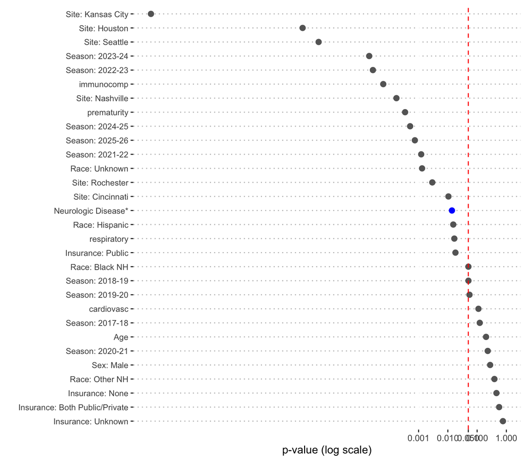

**Interpretation:** While the proportional odds model provides a parsimonious summary, the violations suggest neurologic disease may have differential effects at different severity thresholds. The binary severity sensitivity analysis (below) provides a complementary approach less sensitive to these violations.

# 6 Severity Distribution

```r
# Calculate severity proportions
sev.dist <- hmpv.cases[, .N, by = .(neuro.status, severity)]
sev.dist[, prop := N / sum(N), by = neuro.status]
```

Figure 3 shows the distribution of illness severity among HMPV-positive cases, stratified by neurologic status.

Figure 3: Severity distribution among HMPV-positive cases

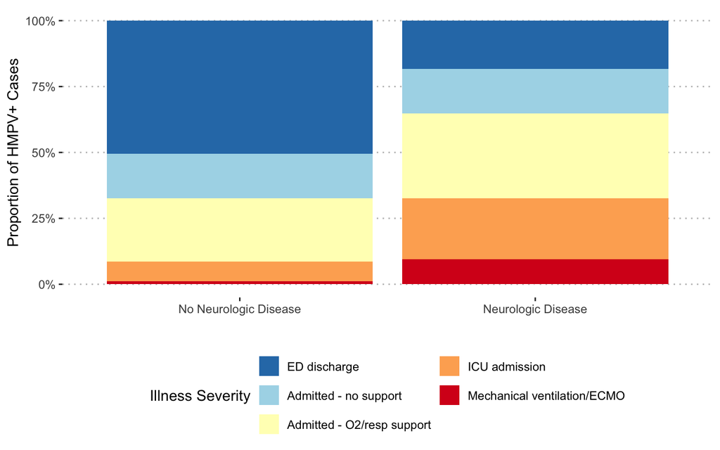

# 7 Comparison to Pittsburgh 2016-21 Findings

**Previous single-site findings (Pittsburgh only):**

- HMPV infection risk: OR = 1.75 (95% CI: 1.19, 2.56)
- HMPV severity: OR = 4.80 (95% CI: 2.01, 11.47)

**Current multisite findings:**

```r
# Extract ORs from models
infection.or <- exp(coef(fit.adj)["neuro.statusNeurologic Disease"])
infection.ci <- exp(confint.default(
  fit.adj, "neuro.statusNeurologic Disease"))

severity.or <- exp(coef(fit.severity)["neuro.statusNeurologic Disease"])
severity.ci <- exp(confint.default(
  fit.severity, "neuro.statusNeurologic Disease"))

comparison <- data.frame(
  Outcome = c("HMPV Infection Risk", "HMPV Severity (among HMPV+)"),
  OR = c(infection.or, severity.or),
  CI_Lower = c(infection.ci[1], severity.ci[1]),
  CI_Upper = c(infection.ci[2], severity.ci[2]))
```

| Outcome | AOR | 95% CI Lower | 95% CI Upper |
| --- | --- | --- | --- |
| HMPV Infection Risk | 1.10 | 0.99 | 1.23 |
| HMPV Severity (among HMPV+) | 2.93 | 2.37 | 3.61 |

## 8 Sensitivity Analyses

## 8.1 Model Without Site/Year Adjustment

```r
fit.no.site <- glm(
  hmpv.pos ~ neuro.status + c_ageyears + sexch + c_race_int +
    insurance.cat + respiratory.cond + cardiovasc.cond +
    immunocomp.cond + prematurity.cond,
  data = inc, family = binomial)

tbl.no.site <- tbl_regression(
  fit.no.site,
  label = desc.labs,
  tidy_fun = tidy.glm.wald,
  exponentiate = TRUE,
  include = neuro.status) |>
  bold_p() |>
  modify_header(estimate = "**AOR**")
```

| **Characteristic** | **AOR** | **95% CI** | **p-value** |
| --- | --- | --- | --- |
| Neurologic/neuromuscular disease |  |  |  |
| No Neurologic Disease | — | — |  |
| Neurologic Disease | 1.07 | 0.96, 1.20 | 0.2 |

Abbreviations: CI = Confidence Interval, OR = Odds Ratio

## 8.2 Dichotomous Severity Outcome

```r
# Define severe illness as ICU admission or MV/ECMO
hmpv.cases[, severe := severity %in% c("ICU admission",
                                       "Mechanical ventilation/ECMO")]

fit.severe.binary <- glm(
  severe ~ neuro.status + c_ageyears + sexch + c_race_int +
    insurance.cat + respiratory.cond + cardiovasc.cond +
    immunocomp.cond + prematurity.cond + studysite + c_ariyear,
  data = hmpv.cases,
  family = binomial)

tbl.severe.binary <- tbl_regression(
  fit.severe.binary,
  label = desc.labs,
  tidy_fun = tidy.glm.wald,
  exponentiate = TRUE,
  include = neuro.status) |>
  bold_p() |>
  modify_header(estimate = "**AOR**") |>
  modify_footnote(
    estimate ~ "Adjusted odds ratio for severe illness (ICU/MV/ECMO)")
```

| **Characteristic** | **AOR**<sup>1</sup> | **95% CI** | **p-value** |
| --- | --- | --- | --- |
| Neurologic/neuromuscular disease |  |  |  |
| No Neurologic Disease | — | — |  |
| Neurologic Disease | 3.41 | 2.59, 4.48 | <0.001 |

<sup>1</sup> Adjusted odds ratio for severe illness (ICU/MV/ECMO)  
Abbreviations: CI = Confidence Interval, OR = Odds Ratio